[figure not shown]

# Introduction to R programming

*Natalia Vilor-Tejedor*: natalia.vilortejedor@crg.eu

# Getting started

## Why R?

R has a number of advantages compared to other statistical software tools (i.e. SAS, SPSS, Stata, etc ...).

- Open-source (It is free!!!)
- Cross-platform (Windows, Mac, Linux)
- Large active, helpful and friendly user base
- Updated regularly
- Extremely flexible and can do or be made to do just about anything
- Amazing graphical capabilities

## Installing R

- Navigate to the Comprehensive R Archive Network (CRAN) website at http://cran.es.r-project.org.
- At the top of the page click the appropiate link for your operating system(Windows, Linux, Mac) i.e. the R distribution under Windows OS is distributed as an installer with the name R-X.Y.Z-win.exe
- Run the executable you just downloaded (Most updated 3.3.1 24/10/2016).

## Installing RStudio

Once R is installed, we can proceed with RStudio installation.

- Navigate to R studio website at http://www.rstudio.com
- Download Rstudio Desktop (Personal License - Free)
- Run the executable you just downloaded.

## The Very Basics of the R Interpreter

### Working directory

Your working directory is the folder on your computer in which you are currently working. When you ask R to open a certain file, it will look in the working directory for this file and when you tell R to save a data file or figure, it will save it in the working directory.

- Start R by double-clicking on the R desktop icon.
- You can check which is your current working directory:

```r
getwd()
```

'C:/Users/NVILORTEJEDOR'

- Defining working directory: Before start an R session, it is important to specify your working directory, where your files and scripts are stored.

```r
setwd("C:/Users/NVILORTEJEDOR/Desktop/Project")
getwd()
```

'C:/Users/NVILORTEJEDOR/Desktop/Project'

### Libraries

R can do many statistical and data analyses. They are organized in so-called packages or libraries. With the standard installation, most common packages are installed.

To get a list of all installed packages, go to the packages window or type `library()` in the console window. If the box in front of the package name is ticked, the package is loaded (activated) and can be used.

- Install the package: type in the command window:

```r
install.packages("survival")
install.github(".....")
```

```r
library("survival")
```

# Basic R Usage

R can be used as a calculator. You can just type your equation and execute the command.

**Example:** Addition of two values

```r
3 + 6
```

9

In general, by using the <-, you can assign a value to an object.

```r
x <- 3
```

Now `x` is called a variable and it appears in the **workspace window**, which means that R stores the value of `x` in its memory and it can be used later.

If you type the name of a variable, the current value of the variable will be printed

```r
x
```

3

## Data types

- Numeric data: 1, 2, 3

```r
x <- c(1, 2, 3)
x
is.numeric(x)
```

1. 1

2. 2

3. 3

TRUE

- Character data: "a", "b", "c"

```r
x <- c("1", "2", "3")
x
```

1. '1'

2. '2'

3. '3'

- Vectors (1D)

```r
myVec <- 1:10
names(myVec) <- letters[1:10]
myVec
```

**a**

1

**b**

2

**c**

3

**d**

4

**e**

5

**f**

6

**g**

7

**h**

8

**i**

9

**j**

10

- Matrices (2D): two dimensional structures with data of same type

```r
myMA <- matrix(1:30, 3, 10, byrow = TRUE)
myMA
class(myMA)
```

| 1 | 2 | 3 | 4 | 5 | 6 | 7 | 8 | 9 | 10 |
| --- | --- | --- | --- | --- | --- | --- | --- | --- | --- |
| 11 | 12 | 13 | 14 | 15 | 16 | 17 | 18 | 19 | 20 |
| 21 | 22 | 23 | 24 | 25 | 26 | 27 | 28 | 29 | 30 |

'matrix'

- Data Frames (2D): two dimensional structures with variable data types

```r
myDF <- data.frame(Col1=c(1,2,3,4,5,6,7,8,9,10), Col2=10:1)
myDF
```

| Col1 | Col2 |
| --- | --- |
| 1 | 10 |
| 2 | 9 |
| 3 | 8 |
| 4 | 7 |
| 5 | 6 |
| 6 | 5 |
| 7 | 4 |
| 8 | 3 |
| 9 | 2 |
| 10 | 1 |

## Functions

A function is an interface to the code, explicitly specified by a set of parameters, that allows to encapsulate an R code that need to be executed numerous times, perhaps under slightly different conditions.

**Example:** If you would like to compute the mean of three elements you could type:

```r
(3+4+5)/3
```

4

But when the vector is very long, this is very boring and time-consuming work. This is why things you do often are automated in so-called functions. Some functions are standard in R or in one of the packages. You can also program your own functions. When you use a function to compute a mean, you'll type:

```r
b <- c(3,4,5)
mean(b)
mean(myDF$Col1)
```

4

5.5

### R's Help Function

The first thing to do if you have a question about one of R's functions is to ask R:

```r
?mean
help(mean)
```

A help page will appear with the following sections (there may be others):

- `Description`: Purpose of the function
- `Usage`: An example of a typical implementation
- `Arguments`: A list of the arguments you can supply to the function
- `Details`: more detailed information about the function and its arguments
- `Value`: Information about the likely output of a function
- `References`: citations which can often be very useful
- `Examples`: example code

### Basic function structure:

Define a `function()` requires predefine:

- a name
- at least one argument
- a body of code that does something

```r
natalia <- function(x){
x <- x+2
return(x)
}

natalia(x=4)
```

6

For example, we can create a function that calculates the square of a number:

```r
square <- function(x) {
square <- x * x
return(square)
}
```

Once a function is written, it can be used just by invoking the name of the function followed by the values that we pass to the arguments, separated by commas and between parentheses. For example, we can call our function `square()` for computing the square of a number or vector:

```r
square(5)
square(c(1, 3, 5))
```

25

1. 1

2. 9

3. 25

As a result, a function usually should return an object, and it can be kept in a variable, and then, print this variable:

```r
num <- square(3)
num
```

9

## Plots

R can make graphs. The following is a very simple example:

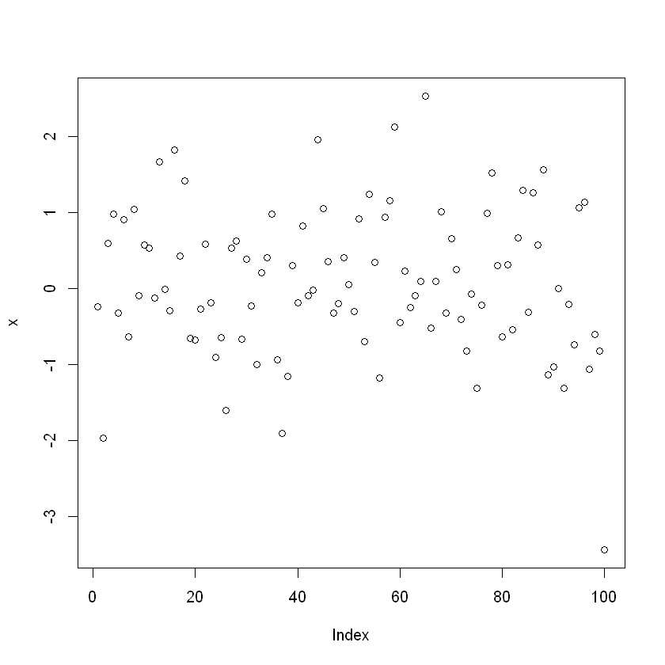

```r
x <- rnorm(100) #  100 random numbers are assigned to the variable x, which becomes a vector by this operation.
# We show these numbers on the screen.
plot(x) # all these values are plotted
```

The general function for creating graphs in R is `plot( )`. Plotting is an important statistical activity. So it should not come as a surprise that R has many plotting facilities.

### Principal graphical representations

Useful links with examples on creating graphs from Quick-R website http://www.statmethods.net:

[**Histograms**](http://www.statmethods.net/graphs/density.html) `hist()`

[**Density plots**](http://www.statmethods.net/graphs/density.html) `density()`

[**Dot plots**](http://www.statmethods.net/graphs/dot.html) `dotchart()`

[**Bar plots**](http://www.statmethods.net/graphs/bar.html) `barplot()`

[**Line charts**](http://www.statmethods.net/graphs/line.html) `lines()`

[**Pie charts**](http://www.statmethods.net/graphs/pie.html) `pie()`

[**Box plots**](http://www.statmethods.net/graphs/boxplot.html) `boxplot()`

[**Scatter plots**](http://www.statmethods.net/graphs/scatterplot.html) `scatterplot()`

[**Graphical parameters**](http://www.statmethods.net/advgraphs/parameters.html) `par()`

## Reading and writing data files

There are many ways to write data from within the R environment to files, and to read data from files. The following lines illustrate the essential:

```r
d <- data.frame(a = c(3,4,5), b = c(12,43,54))
d
write.table(d, file="tst0.txt",row.names = FALSE, quote=F)
```

| a | b |
| --- | --- |
| 3 | 12 |
| 4 | 43 |
| 5 | 54 |

```r
d2 <- read.table(file="tst0.txt", header=TRUE)
d2
```

| a | b |
| --- | --- |
| 3 | 12 |
| 4 | 43 |
| 5 | 54 |

### **Load the dataset:** `myData.txt`

```r
rdatos <- read.table("myData.txt", header=T)
```

# Basic data management

## Recoding variables

Recoding involves creating new values of a variable conditional on the existing values of the same and/or other variables. For example, you may want to:

- Change a continuous variable into a set of categories
- Create a pass/fail variable based on a set of cutoff scores
- Replace miscoded values with correct values

```r
rdatos$Agecat[rdatos$age > 70] <- "Elder"
rdatos$Agecat[rdatos$age  >= 50 & rdatos$age <= 70] <- "Middle Aged"
rdatos$Agecat[rdatos$age < 50] <- "Young"
head(rdatos)
```

| ID | bmi | exposure | age | sex | Agecat |
| --- | --- | --- | --- | --- | --- |
| 1 | 27.89655 | 14.947392 | 44 | 0 | Young |
| 2 | 21.27439 | 1.669446 | 56 | 1 | Middle Aged |
| 3 | 19.19011 | 7.823265 | 44 | 0 | Young |
| 4 | 20.07581 | 8.653840 | 46 | 0 | Young |
| 5 | 20.51702 | 10.745969 | 51 | 1 | Middle Aged |
| 6 | 25.81578 | 15.906069 | 25 | 1 | Young |

## Renaming variables

You can change variable names. Let's say that you want to change the variables `age` to `Age0`.

```r
names(rdatos)
names(rdatos)[4] <- "Age0"
head(rdatos)
```

1. 'ID'

2. 'bmi'

3. 'exposure'

4. 'age'

5. 'sex'

6. 'Agecat'

| ID | bmi | exposure | Age0 | sex | Agecat |
| --- | --- | --- | --- | --- | --- |
| 1 | 27.89655 | 14.947392 | 44 | 0 | Young |
| 2 | 21.27439 | 1.669446 | 56 | 1 | Middle Aged |
| 3 | 19.19011 | 7.823265 | 44 | 0 | Young |
| 4 | 20.07581 | 8.653840 | 46 | 0 | Young |
| 5 | 20.51702 | 10.745969 | 51 | 1 | Middle Aged |
| 6 | 25.81578 | 15.906069 | 25 | 1 | Young |

## Sorting data

Sometimes, viewing a dataset in a sorted order can tell you quite a bit about the data. To sort a data frame in R, use the `order()` function.

**Example:** The statement:

```r
newdata <- rdatos[order(rdatos$Age0),]
newdata[1:10,]
```

|  | ID | bmi | exposure | Age0 | sex | Agecat |
| --- | --- | --- | --- | --- | --- | --- |
| 45 | 45 | 23.89629 | 22.40461889 | 19 | 0 | Young |
| 65 | 65 | 21.16329 | 8.74142816 | 20 | 0 | Young |
| 9 | 9 | 26.45421 | 14.64042338 | 21 | 0 | Young |
| 22 | 22 | 26.43817 | 13.05120875 | 21 | 1 | Young |
| 49 | 49 | 22.92092 | 12.63893400 | 22 | 0 | Young |
| 50 | 50 | 20.94282 | 12.43764474 | 22 | 1 | Young |
| 70 | 70 | 24.58324 | -0.06978132 | 22 | 0 | Young |
| 16 | 16 | 22.51076 | 7.07704477 | 24 | 1 | Young |
| 24 | 24 | 19.02832 | 12.80285827 | 24 | 0 | Young |
| 27 | 27 | 22.06751 | 17.99063562 | 24 | 1 | Young |

creates a new dataset containing rows sorted from youngest to oldest.

## Merging datasets

If your data exist in multiple locations, you'll need to combine them before moving forward.

### Adding columns

To merge two data frames (datasets) horizontally, you use the merge() function. In most cases, two data frames are joined by one or more common key variables.

**Example**:

```r
dataframeA <- data.frame(ID= seq(1,100,1), Country=rep(c("Spain", "EEUU", "Iceland"), c(25,50,25)))
```

To merge `rdatos` and `dataframeA` by ID:

```r
total <- merge(rdatos,dataframeA, by="ID")
head(total)
```

| ID | bmi | exposure | Age0 | sex | Agecat | Country |
| --- | --- | --- | --- | --- | --- | --- |
| 1 | 27.89655 | 14.947392 | 44 | 0 | Young | Spain |
| 2 | 21.27439 | 1.669446 | 56 | 1 | Middle Aged | Spain |
| 3 | 19.19011 | 7.823265 | 44 | 0 | Young | Spain |
| 4 | 20.07581 | 8.653840 | 46 | 0 | Young | Spain |
| 5 | 20.51702 | 10.745969 | 51 | 1 | Middle Aged | Spain |
| 6 | 25.81578 | 15.906069 | 25 | 1 | Young | Spain |

## Subsetting datasets

R has powerful indexing features for accessing the elements of an object. These features can be used to select and exclude variables, observations, or both.

### Selecting (keeping) variables

It's a common practice to create a new dataset from a limited number of variables chosen from a larger dataset. The elements of a data frame are accessed using the notation dataframe[row indices, column indices]. You can use this to select variables.

**Example**:

The statement:

```r
newdata <- rdatos[1,1]
head(newdata)
```

1

The statement

```r
myvars <- c("ID", "Age0")
rdatosmyvars <- rdatos[,myvars]
head(rdatosmyvars)
```

| ID | Age0 |
| --- | --- |
| 1 | 44 |
| 2 | 56 |
| 3 | 44 |
| 4 | 46 |
| 5 | 51 |
| 6 | 25 |

### Excluding (dropping) variables

```r
newdata <- rdatos[,-c(2,4)]
head(newdata)
```

| ID | exposure | sex | Agecat |
| --- | --- | --- | --- |
| 1 | 14.947392 | 0 | Young |
| 2 | 1.669446 | 1 | Middle Aged |
| 3 | 7.823265 | 0 | Young |
| 4 | 8.653840 | 0 | Young |
| 5 | 10.745969 | 1 | Middle Aged |
| 6 | 15.906069 | 1 | Young |

### Selecting observations

Selecting or excluding observations (rows) is typically a key aspect of successful data preparation and analysis.

**Examples**

- Ask for rows 1 through 3 (first three observations)

```r
newdata <- rdatos[1:3,]
head(newdata)
```

| ID | bmi | exposure | Age0 | sex | Agecat |
| --- | --- | --- | --- | --- | --- |
| 1 | 27.89655 | 14.947392 | 44 | 0 | Young |
| 2 | 21.27439 | 1.669446 | 56 | 1 | Middle Aged |
| 3 | 19.19011 | 7.823265 | 44 | 0 | Young |

```r
newdata <- rdatos[which(rdatos$sex==0 & rdatos$Agecat > "Middle Aged"),]
head(newdata)
```

|  | ID | bmi | exposure | Age0 | sex | Agecat |
| --- | --- | --- | --- | --- | --- | --- |
| 1 | 1 | 27.89655 | 14.947392 | 44 | 0 | Young |
| 3 | 3 | 19.19011 | 7.823265 | 44 | 0 | Young |
| 4 | 4 | 20.07581 | 8.653840 | 46 | 0 | Young |
| 8 | 8 | 22.95996 | 18.087734 | 33 | 0 | Young |
| 9 | 9 | 26.45421 | 14.640423 | 21 | 0 | Young |
| 11 | 11 | 19.79639 | 13.682647 | 48 | 0 | Young |

### The `subset()` function

The subset function is probably the easiest way to select variables and observations.

**Examples**

```r
newdata <- subset(rdatos, Age0 >= 55 & exposure < 14)
head(newdata)
```

|  | ID | bmi | exposure | Age0 | sex | Agecat |
| --- | --- | --- | --- | --- | --- | --- |
| 2 | 2 | 21.27439 | 1.669446 | 56 | 1 | Middle Aged |
| 17 | 17 | 20.48206 | 7.546134 | 64 | 1 | Middle Aged |
| 18 | 18 | 24.15121 | 11.691675 | 61 | 1 | Middle Aged |
| 23 | 23 | 21.59055 | 6.491538 | 56 | 1 | Middle Aged |
| 30 | 30 | 20.44628 | 3.814812 | 62 | 1 | Middle Aged |
| 39 | 39 | 24.30224 | 10.618682 | 57 | 1 | Middle Aged |

## Conditionals

### `if()` statement:

One of the most basic programing concepts involves evaluating conditional statements and then performing some action based on the evaluation. Let's write a very simple conditional using the `if()` control-flow construct. The `if()` construct is simply a control statement that takes a conditional statement as its argument and then depending on the evaluation initiates some other function.

```r
x <- 3
if (x!=3) {
    print("Perfect!")
} else {
    print("No perfect!")
}
```

```
[1] "No perfect!"
```

```r
if (1 + 1 == 3) print (" Perfect!")
```

### `else()` statement:

If we wanted to R to also do something if the conditional is FALSE we would have to add the else statement.

```r
if (1 + 1 == 3) print (" Perfect!")  else print ("Wrong")
```

```
[1] "Wrong"
```

### `ifelse()` statement

Instead of using the `if()` and else control statements, you can just use the `ifelse()` function. The function takes the arguments test, yes and no.

```r
Z <- 1:10
Z.new <- ifelse(test = Z > 2 & Z < 8 , yes = " Yes " , no = " No")
Z.new
```

1. ' No'

2. ' No'

3. ' Yes '

4. ' Yes '

5. ' Yes '

6. ' Yes '

7. ' Yes '

8. ' No'

9. ' No'

10. ' No'

# Exercices

We will use a simulated data set which contains: `sex`: Sex status variable; `bmi`: Body Mass Index; `age`: Individual's Age variable; `exposure`: Continuous exposure variable.

```r
sex <- rbinom(100, 1, 0.5)
bmi <- runif(100,19,28)
age <- round(runif(100,18,65))
exposure <- rnorm(100, 10, 5)
myData <- data.frame(bmi, exposure, age, sex)
```

**Step 1:** Read and Inspect data `myData.txt`. Save the data in a R object named `myData.txt`.

**Step 2:** Transform to factor the variable `sex` (`male` as reference level).

**Step 3:** Add to `myData` a dichotomization of `exposure`, named `Ebin`, as a factor with levels `low` (reference level) and `high` with the threshold in the median. [Hint: Explore `ifelse()` function]

**Step 4:** For quantitative variables compute: `min`, `pct 2.5\%`, `median`, `mean`, `pct 97.5\%`, `max`, `sd`, `N` and histograms. [Hint: Explore `summary()` function]

**Step 5:** Compute a scatter plot between `exposure` and `bmi`.

[figure not shown]